# Pokémon Power Creep Analysis

# 11. Time-Split Cross-Validation

Train on Gen ≤5, Test on Gen ≥6.

```r
# Split data and retain full factor levels to avoid "new levels" issues
train_data <- pokemon %>%
  filter(gen_numeric <= 5) %>%
  mutate(
    gen = factor(gen, levels = levels(pokemon$gen)),
    rarity = factor(rarity, levels = levels(pokemon$rarity))
  )

test_data <- pokemon %>%
  filter(gen_numeric >= 6) %>%
  mutate(
    gen = factor(gen, levels = levels(pokemon$gen)),
    rarity = factor(rarity, levels = levels(pokemon$rarity))
  )

cat("Training set (Gen 1-5):", nrow(train_data), "Pokémon\n")
```

```
## Training set (Gen 1-5): 649 Pokémon
```

```r
cat("Test set (Gen 6-9):", nrow(test_data), "Pokémon\n")
```

```
## Test set (Gen 6-9): 375 Pokémon
```

```r
# Train models on Gen 1-5
# Use numeric generation to avoid factor level issues when predicting on newer gens
cv_model_lm <- lm(attack ~ gen_numeric + hp + defense + sp_attack + sp_defense + speed +
                    rarity + weight_kg, data = train_data)

cv_model_glm <- glm(attack ~ gen_numeric + hp + defense + sp_attack + sp_defense + speed +
                      rarity + weight_kg, data = train_data, family = Gamma(link = "log"))

# Predict on Gen 6-9
pred_lm <- predict(cv_model_lm, newdata = test_data)
pred_glm <- predict(cv_model_glm, newdata = test_data, type = "response")

# Compute metrics
rmse_lm <- sqrt(mean((test_data$attack - pred_lm)^2))
mae_lm <- mean(abs(test_data$attack - pred_lm))
r2_lm <- 1 - sum((test_data$attack - pred_lm)^2) / sum((test_data$attack - mean(test_data$attack))^2)

rmse_glm <- sqrt(mean((test_data$attack - pred_glm)^2))
mae_glm <- mean(abs(test_data$attack - pred_glm))
r2_glm <- 1 - sum((test_data$attack - pred_glm)^2) / sum((test_data$attack - mean(test_data$attack))^2)

cat("--- Time-Split CV Results ---\n")
```

```
## --- Time-Split CV Results ---
```

```r
cat("OLS Model:\n")
```

```
## OLS Model:
```

```r
cat("  RMSE:", rmse_lm, "\n")
```

```
##   RMSE: 24.02205
```

```r
cat("  MAE:", mae_lm, "\n")
```

```
##   MAE: 18.84692
```

```r
cat("  R²:", r2_lm, "\n")
```

```
##   R²: 0.3665281
```

```r
cat("\nGamma GLM:\n")
```

```
##
## Gamma GLM:
```

```r
cat("  RMSE:", rmse_glm, "\n")
```

```
##   RMSE: 30.5401
```

```r
cat("  MAE:", mae_glm, "\n")
```

```
##   MAE: 21.22082
```

```r
cat("  R²:", r2_glm, "\n")
```

```
##   R²: -0.02387762
```

**Findings:** OLS generalizes better to future generations (RMSE 24) than Gamma GLM (RMSE 30). The degradation from 10-fold CV (~21) to time-split (~24) suggests the generation effect is not perfectly linear — future generations don’t follow the same pattern as past ones. This is a caveat for the power creep claim.

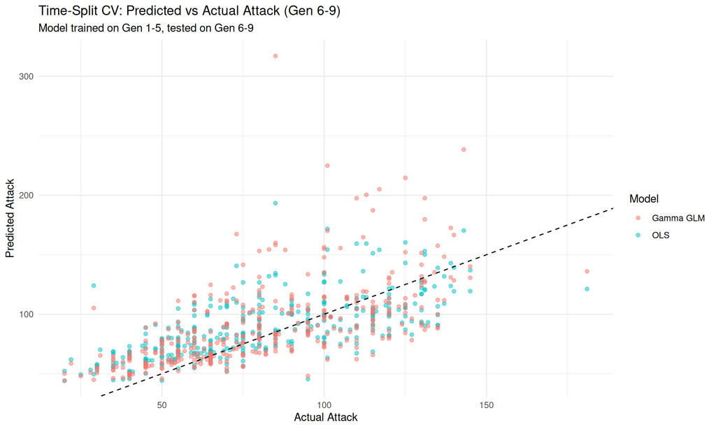

```r
# Visualize predictions vs actual
pred_comparison <- data.frame(
  actual = test_data$attack,
  pred_lm = pred_lm,
  pred_glm = pred_glm,
  gen = test_data$gen
)

p_cv <- ggplot(pred_comparison, aes(x = actual)) +
  geom_point(aes(y = pred_lm, color = "OLS"), alpha = 0.5) +
  geom_point(aes(y = pred_glm, color = "Gamma GLM"), alpha = 0.5) +
  geom_abline(intercept = 0, slope = 1, linetype = "dashed", color = "black") +
  labs(title = "Time-Split CV: Predicted vs Actual Attack (Gen 6-9)",
       subtitle = "Model trained on Gen 1-5, tested on Gen 6-9",
       x = "Actual Attack", y = "Predicted Attack",
       color = "Model") +
  theme_minimal()
print(p_cv)
```

# 12. Robust Regression (Huber)

```r
# Fit robust regression (Huber M-estimator)
model_robust <- rlm(attack ~ gen + hp + defense + sp_attack + sp_defense + speed +
                      rarity + weight_kg, data = pokemon)
cat("--- Robust Regression (Huber) ---\n")
```

```
## --- Robust Regression (Huber) ---
```

```r
summary(model_robust)
```

```
##
## Call: rlm(formula = attack ~ gen + hp + defense + sp_attack + sp_defense +
##     speed + rarity + weight_kg, data = pokemon)
## Residuals:
##      Min       1Q   Median       3Q      Max
## -104.734  -14.186   -0.807   13.602   79.990
##
## Coefficients:
##                    Value   Std. Error t value
## (Intercept)        10.5265  3.3538     3.1387
## gen2               -4.0773  2.7900    -1.4614
## gen3               -1.2467  2.5543    -0.4881
## gen4                0.3311  2.7319     0.1212
## gen5                4.3770  2.4596     1.7795
## gen6               -3.1888  3.0927    -1.0311
## gen7                4.8701  2.9691     1.6403
## gen8                3.9390  2.8222     1.3957
## gen9               -1.9130  2.6541    -0.7208
## hp                  0.4155  0.0310    13.4228
## defense             0.4134  0.0291    14.2275
## sp_attack          -0.0260  0.0292    -0.8916
## sp_defense         -0.2218  0.0334    -6.6328
## speed               0.3320  0.0267    12.4356
## raritySubLegendary  0.1972  3.4614     0.0570
## rarityLegendary     4.4120  5.2545     0.8397
## rarityMythical      4.9048  5.0694     0.9675
## weight_kg           0.0251  0.0072     3.4694
##
## Residual standard error: 20.65 on 1006 degrees of freedom
```

```r
# Compare with OLS
cat("\nComparison of coefficients (OLS vs Robust):\n")
```

```
##
## Comparison of coefficients (OLS vs Robust):
```

```r
coef_comparison <- data.frame(
  OLS = coef(model_full)[names(coef(model_robust))],
  Robust = coef(model_robust)
)
print(round(coef_comparison, 4))
```

```
##                        OLS  Robust
## (Intercept)        46.8893 10.5265
## gen2               -5.4457 -4.0773
## gen3                1.5679 -1.2467
## gen4                0.9774  0.3311
## gen5                5.7210  4.3770
## gen6               -1.9391 -3.1888
## gen7                4.9676  4.8701
## gen8                4.5052  3.9390
## gen9               -1.3953 -1.9130
## hp                  0.2663  0.4155
## defense             0.3430  0.4134
## sp_attack          -0.0441 -0.0260
## sp_defense         -0.2679 -0.2218
## speed               0.2518  0.3320
## raritySubLegendary -1.4791  0.1972
## rarityLegendary     5.8068  4.4120
## rarityMythical      4.4635  4.9048
## weight_kg           0.0191  0.0251
```

**Findings:** Robust regression coefficients are similar to OLS, indicating outliers don’t drastically affect the generation effect estimates. This strengthens confidence in the OLS results.

# 13. Final Analysis: Is There Power Creep?

## 13.1 Generation Coefficients

```r
# Extract generation coefficients from models - including all three datasets
gen_coefs <- data.frame(
  Generation = paste0("Gen", 2:9),
  OLS_Full = coef(model_full)[grep("^gen", names(coef(model_full)))],
  OLS_Clean = coef(model_full_clean)[grep("^gen", names(coef(model_full_clean)))],
  OLS_Normal = coef(model_full_normal)[grep("^gen", names(coef(model_full_normal)))],
  Robust = coef(model_robust)[grep("^gen", names(coef(model_robust)))]
)
rownames(gen_coefs) <- NULL

cat("--- Generation Coefficients (relative to Gen 1) ---\n")
```

```
## --- Generation Coefficients (relative to Gen 1) ---
```

```r
cat("Columns: OLS_Full = full data, OLS_Clean = outlier-free, OLS_Normal = normal rarity only, Robust = Huber\n\n")
```

```
## Columns: OLS_Full = full data, OLS_Clean = outlier-free, OLS_Normal = normal rarity only, Robust = Huber
```

```r
gen_coefs %>%
  mutate(across(where(is.numeric), ~ round(.x, 3))) %>%
  knitr::kable()
```

| Generation | OLS_Full | OLS_Clean | OLS_Normal | Robust |
| --- | --- | --- | --- | --- |
| Gen2 | -5.446 | -6.435 | -5.821 | -4.077 |
| Gen3 | 1.568 | 0.355 | 1.146 | -1.247 |
| Gen4 | 0.977 | 1.149 | 1.109 | 0.331 |
| Gen5 | 5.721 | 5.827 | 5.509 | 4.377 |
| Gen6 | -1.939 | -2.083 | -3.327 | -3.189 |
| Gen7 | 4.968 | 4.600 | 4.927 | 4.870 |
| Gen8 | 4.505 | 4.112 | 4.298 | 3.939 |
| Gen9 | -1.395 | -1.501 | -1.512 | -1.913 |

**Findings:** Compare coefficients across all datasets. The OLS_Normal column shows the generation effect among regular Pokémon only — similar values to OLS_Full indicate power creep isn’t driven by legendaries.

## 13.2 Linear Trend Analysis

```r
# Test linear trend in generation - FULL DATA
trend_model <- lm(attack ~ gen_numeric + hp + defense + sp_attack + sp_defense +
                    speed + rarity, data = pokemon)
cat("--- Linear Trend of Generation on Attack (Full Data) ---\n")
```

```
## --- Linear Trend of Generation on Attack (Full Data) ---
```

```r
cat("Coefficient of gen_numeric:", round(coef(trend_model)["gen_numeric"], 3), "\n")
```

```
## Coefficient of gen_numeric: 0.481
```

```r
cat("p-value:", format(summary(trend_model)$coefficients["gen_numeric", "Pr(>|t|)"], digits = 4), "\n")
```

```
## p-value: 0.07026
```

```r
# OUTLIER-FREE DATA
trend_model_clean <- lm(attack ~ gen_numeric + hp + defense + sp_attack + sp_defense +
                          speed + rarity, data = pokemon_clean)
cat("\n--- Linear Trend of Generation on Attack (Outlier-Free) ---\n")
```

```
##
## --- Linear Trend of Generation on Attack (Outlier-Free) ---
```

```r
cat("Coefficient of gen_numeric:", round(coef(trend_model_clean)["gen_numeric"], 3), "\n")
```

```
## Coefficient of gen_numeric: 0.492
```

```r
cat("p-value:", format(summary(trend_model_clean)$coefficients["gen_numeric", "Pr(>|t|)"], digits = 4), "\n")
```

```
## p-value: 0.06619
```

```r
# NORMAL RARITY ONLY (no rarity predictor)
trend_model_normal <- lm(attack ~ gen_numeric + hp + defense + sp_attack + sp_defense +
                           speed, data = pokemon_normal)
cat("\n--- Linear Trend of Generation on Attack (Normal Only) ---\n")
```

```
##
## --- Linear Trend of Generation on Attack (Normal Only) ---
```

```r
cat("Coefficient of gen_numeric:", round(coef(trend_model_normal)["gen_numeric"], 3), "\n")
```

```
## Coefficient of gen_numeric: 0.413
```

```r
cat("p-value:", format(summary(trend_model_normal)$coefficients["gen_numeric", "Pr(>|t|)"], digits = 4), "\n")
```

```
## p-value: 0.1293
```

```r
cat("\n--- Interpretation ---\n")
```

```
##
## --- Interpretation ---
```

```r
cat("Full data: Each generation increases attack by ~", round(coef(trend_model)["gen_numeric"], 1), " points\n")
```

```
## Full data: Each generation increases attack by ~ 0.5  points
```

```r
cat("Outlier-free: Each generation increases attack by ~", round(coef(trend_model_clean)["gen_numeric"], 1), " points\n")
```

```
## Outlier-free: Each generation increases attack by ~ 0.5  points
```

```r
cat("Normal-only: Each generation increases attack by ~", round(coef(trend_model_normal)["gen_numeric"], 1), " points\n")
```

```
## Normal-only: Each generation increases attack by ~ 0.4  points
```

## 13.3 Mean Attack by Generation

```r
# Overall mean attack by generation - BOTH DATASETS
mean_by_gen <- pokemon %>%
  group_by(gen) %>%
  summarise(mean_attack = mean(attack)) %>%
  arrange(gen)

mean_by_gen_clean <- pokemon_clean %>%
  group_by(gen) %>%
  summarise(mean_attack = mean(attack)) %>%
  arrange(gen)

mean_by_gen_normal <- pokemon_normal %>%
  group_by(gen) %>%
  summarise(mean_attack = mean(attack)) %>%
  arrange(gen)

cat("--- Mean Attack by Generation (All Three Datasets) ---\n")
```

```
## --- Mean Attack by Generation (All Three Datasets) ---
```

```r
comparison_mean <- data.frame(
  gen = 1:9,
  full = mean_by_gen$mean_attack,
  clean = mean_by_gen_clean$mean_attack,
  normal = mean_by_gen_normal$mean_attack
) %>% mutate(
  diff_clean = round(full - clean, 1),
  diff_normal = round(full - normal, 1)
)
print(comparison_mean)
```

```
##   gen     full    clean   normal diff_clean diff_normal
## 1   1 72.91391 72.06993 72.08904        0.8         0.8
## 2   2 68.26000 64.86022 66.28723        3.4         2.0
## 3   3 73.11111 70.47619 70.60000        2.6         2.5
## 4   4 80.21495 79.05882 76.64516        1.2         3.6
## 5   5 81.03205 81.03205 78.37762        0.0         2.7
## 6   6 72.50000 70.58209 68.75758        1.9         3.7
## 7   7 84.77273 79.49351 78.19355        5.3         6.6
## 8   8 82.88421 80.98889 80.83146        1.9         2.1
## 9   9 82.42500 82.25424 81.38793        0.2         1.0
```

```r
# Calculate trends
trend <- cor(as.numeric(mean_by_gen$gen), mean_by_gen$mean_attack)
trend_clean <- cor(as.numeric(mean_by_gen_clean$gen), mean_by_gen_clean$mean_attack)
trend_normal <- cor(as.numeric(mean_by_gen_normal$gen), mean_by_gen_normal$mean_attack)

cat("\n--- Correlation (gen vs mean_attack) ---\n")
```

```
##
## --- Correlation (gen vs mean_attack) ---
```

```r
cat("Full data:", round(trend, 3), "\n")
```

```
## Full data: 0.757
```

```r
cat("Outlier-free:", round(trend_clean, 3), "\n")
```

```
## Outlier-free: 0.725
```

```r
cat("Normal-only:", round(trend_normal, 3), "\n")
```

```
## Normal-only: 0.732
```

## 13.4 Summary Visualization: Full vs Outlier-Free Trends

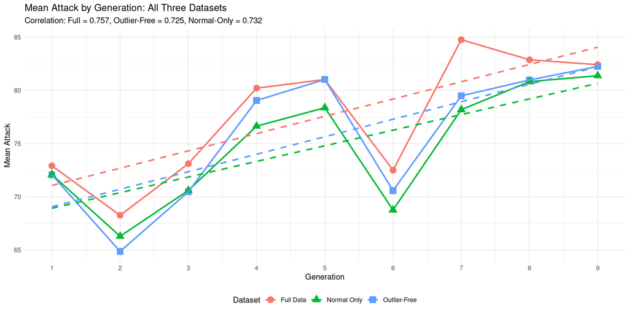

```r
# Create comparison plot of mean attack trends - ALL THREE DATASETS
trend_data <- data.frame(
  gen = rep(1:9, 3),
  mean_attack = c(mean_by_gen$mean_attack, mean_by_gen_clean$mean_attack, mean_by_gen_normal$mean_attack),
  dataset = rep(c("Full Data", "Outlier-Free", "Normal Only"), each = 9)
)

p_trend_compare <- ggplot(trend_data, aes(x = gen, y = mean_attack, color = dataset, shape = dataset)) +
  geom_point(size = 4) +
  geom_line(linewidth = 1) +
  geom_smooth(method = "lm", se = FALSE, linetype = "dashed", alpha = 0.5) +
  scale_x_continuous(breaks = 1:9) +
  labs(title = "Mean Attack by Generation: All Three Datasets",
       subtitle = paste0("Correlation: Full = ", round(trend, 3),
                        ", Outlier-Free = ", round(trend_clean, 3),
                        ", Normal-Only = ", round(trend_normal, 3)),
       x = "Generation", y = "Mean Attack",
       color = "Dataset", shape = "Dataset") +
  theme_minimal() +
  theme(legend.position = "bottom")
print(p_trend_compare)
```

**Findings:** This visualization compares generation trends across all three datasets. The Normal-only line shows power creep among regular Pokémon — if it tracks the Full data line, legendaries aren’t inflating the trend.

# 14. Additional Verification Checks for Power Creep

These checks address potential confounds and strengthen (or weaken) the power creep claim.

## 14.1 Monotonic Trend Test (Jonckheere-Terpstra)

Is there a consistent *ordering* of attack across generations, not just correlation?

```r
# Jonckheere-Terpstra test for ordered alternatives
# H0: No trend; H1: Monotonically increasing trend
# FULL DATA
jt_test <- JonckheereTerpstraTest(pokemon$attack, as.numeric(pokemon$gen),
                                   alternative = "increasing")
cat("--- Jonckheere-Terpstra Test for Monotonic Trend (Full Data) ---\n")
```

```
## --- Jonckheere-Terpstra Test for Monotonic Trend (Full Data) ---
```

```r
print(jt_test)
```

```
##
##  Jonckheere-Terpstra test
##
## data:  pokemon$attack by as.numeric(pokemon$gen)
## JT = 253582, p-value = 2.088e-05
## alternative hypothesis: increasing
```

```r
# OUTLIER-FREE DATA
jt_test_clean <- JonckheereTerpstraTest(pokemon_clean$attack, as.numeric(pokemon_clean$gen),
                                         alternative = "increasing")
cat("\n--- Jonckheere-Terpstra Test for Monotonic Trend (Outlier-Free) ---\n")
```

```
##
## --- Jonckheere-Terpstra Test for Monotonic Trend (Outlier-Free) ---
```

```r
print(jt_test_clean)
```

```
##
##  Jonckheere-Terpstra test
##
## data:  pokemon_clean$attack by as.numeric(pokemon_clean$gen)
## JT = 229008, p-value = 1.614e-05
## alternative hypothesis: increasing
```

```r
cat("\n--- Comparison ---\n")
```

```
##
## --- Comparison ---
```

```r
cat("Full data p-value:", format(jt_test$p.value, digits = 4),
    ifelse(jt_test$p.value < 0.05, "(significant)", "(not significant)"), "\n")
```

```
## Full data p-value: 2.088e-05 (significant)
```

```r
cat("Outlier-free p-value:", format(jt_test_clean$p.value, digits = 4),
    ifelse(jt_test_clean$p.value < 0.05, "(significant)", "(not significant)"), "\n")
```

```
## Outlier-free p-value: 1.614e-05 (significant)
```

**Findings:** Jonckheere-Terpstra test p = 2.09e-05 (full) and p = 1.61e-05 (outlier-free) confirm a significant monotonically increasing trend. This non-parametric test is more appropriate than Pearson correlation because it tests for *ordered* increase, not just linear association. Both datasets show highly significant results.

## 14.2 Rarity Distribution by Generation

Is power creep driven by more legendaries in later generations?

```r
# Check if rarity distribution changes across generations
rarity_by_gen <- pokemon %>%
  group_by(gen, rarity) %>%
  summarise(n = n(), .groups = "drop") %>%
  group_by(gen) %>%
  mutate(prop = n / sum(n)) %>%
  filter(rarity != "Normal")

cat("--- Proportion of Rare Pokémon by Generation ---\n")
```

```
## --- Proportion of Rare Pokémon by Generation ---
```

```r
print(rarity_by_gen %>% pivot_wider(names_from = rarity, values_from = prop, values_fill = 0))
```

```
## # A tibble: 21 × 5
## # Groups:   gen [9]
##    gen       n SubLegendary Legendary Mythical
##    <fct> <int>        <dbl>     <dbl>    <dbl>
##  1 1         3       0.0199   0        0
##  2 1         1       0        0.00662  0.00662
##  3 2         3       0.03     0        0
##  4 2         2       0        0.02     0
##  5 2         1       0        0        0.01
##  6 3         5       0.0370   0        0
##  7 3         3       0        0.0222   0
##  8 3         2       0        0        0.0148
##  9 4         6       0.0561   0        0
## 10 4         3       0        0.0280   0
## # ℹ 11 more rows
```

```r
# Chi-square test: Is rarity distribution independent of generation?
rarity_table <- table(pokemon$gen, pokemon$rarity)
chi_test <- chisq.test(rarity_table)
cat("\nChi-square test (Rarity ~ Generation):\n")
```

```
##
## Chi-square test (Rarity ~ Generation):
```

```r
print(chi_test)
```

```
##
##  Pearson's Chi-squared test
##
## data:  rarity_table
## X-squared = 80.496, df = 24, p-value = 5.072e-08
```

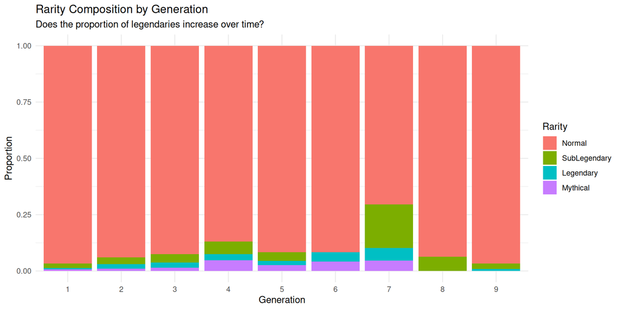

```r
# Visualize
p_rarity_gen <- pokemon %>%
  group_by(gen, rarity) %>%
  summarise(n = n(), .groups = "drop") %>%
  ggplot(aes(x = gen, y = n, fill = rarity)) +
  geom_col(position = "fill") +
  labs(title = "Rarity Composition by Generation",
       subtitle = "Does the proportion of legendaries increase over time?",
       x = "Generation", y = "Proportion", fill = "Rarity") +
  theme_minimal()
print(p_rarity_gen)
```

**Findings:** If later generations have higher proportions of legendary/mythical Pokémon, this could explain the apparent power creep without a true baseline increase.

## 14.3 Power Creep Among Normal Pokémon Only

Test if power creep exists when excluding legendaries. Uses the pre-built `pokemon_normal` dataset.

```r
# pokemon_normal was created in Section 2 - contains only Normal rarity Pokémon
cat("--- Attack by Generation (Normal Pokémon Only) ---\n")
```

```
## --- Attack by Generation (Normal Pokémon Only) ---
```

```r
cat("Dataset size:", nrow(pokemon_normal), "Pokémon\n\n")
```

```
## Dataset size: 934 Pokémon
```

```r
normal_summary <- pokemon_normal %>%
  group_by(gen) %>%
  summarise(n = n(), mean_attack = mean(attack), sd_attack = sd(attack))
print(normal_summary)
```

```
## # A tibble: 9 × 4
##   gen       n mean_attack sd_attack
##   <fct> <int>       <dbl>     <dbl>
## 1 1       146        72.1      26.8
## 2 2        94        66.3      27.8
## 3 3       125        70.6      28.7
## 4 4        93        76.6      30.4
## 5 5       143        78.4      28.5
## 6 6        66        68.8      23.0
## 7 7        62        78.2      29.8
## 8 8        89        80.8      30.8
## 9 9       116        81.4      29.1
```

```r
# Test generation effect on normal Pokémon (simpler model - no rarity needed)
model_normal_check <- lm(attack ~ gen + hp + defense + speed, data = pokemon_normal)
cat("\n--- OLS on Normal Pokémon Only ---\n")
```

```
##
## --- OLS on Normal Pokémon Only ---
```

```r
summary(model_normal_check)
```

```
##
## Call:
## lm(formula = attack ~ gen + hp + defense + speed, data = pokemon_normal)
##
## Residuals:
##      Min       1Q   Median       3Q      Max
## -106.995  -15.342   -0.863   14.124   84.357
##
## Coefficients:
##             Estimate Std. Error t value Pr(>|t|)
## (Intercept)  4.87314    3.38303   1.440   0.1501
## gen2        -5.55297    2.95890  -1.877   0.0609 .
## gen3         1.16056    2.72197   0.426   0.6699
## gen4         1.74004    2.95862   0.588   0.5566
## gen5         4.94952    2.62519   1.885   0.0597 .
## gen6        -5.35089    3.30419  -1.619   0.1057
## gen7         6.12757    3.38777   1.809   0.0708 .
## gen8         4.19150    3.00089   1.397   0.1628
## gen9        -0.59099    2.79994  -0.211   0.8329
## hp           0.36505    0.03040  12.008   <2e-16 ***
## defense      0.37313    0.02709  13.775   <2e-16 ***
## speed        0.27985    0.02720  10.289   <2e-16 ***
## ---
## Signif. codes:  0 '***' 0.001 '**' 0.01 '*' 0.05 '.' 0.1 ' ' 1
##
## Residual standard error: 22.24 on 922 degrees of freedom
## Multiple R-squared:  0.4082, Adjusted R-squared:  0.4012
## F-statistic: 57.83 on 11 and 922 DF,  p-value: < 2.2e-16
```

```r
# Trend correlation for normal only (already computed in 13.3, but shown here for clarity)
trend_normal_check <- cor(as.numeric(normal_summary$gen), normal_summary$mean_attack)
cat("\nCorrelation (gen vs mean_attack) for Normal Pokémon:", round(trend_normal_check, 3), "\n")
```

```
##
## Correlation (gen vs mean_attack) for Normal Pokémon: 0.732
```

```r
# Compare with full dataset
cat("\n--- Comparison with Full Dataset ---\n")
```

```
##
## --- Comparison with Full Dataset ---
```

```r
cat("Full data correlation:", round(trend, 3), "\n")
```

```
## Full data correlation: 0.757
```

```r
cat("Normal-only correlation:", round(trend_normal_check, 3), "\n")
```

```
## Normal-only correlation: 0.732
```

```r
cat("Difference:", round(trend - trend_normal_check, 3), "\n")
```

```
## Difference: 0.025
```

## 14.4 Total Stats Analysis (Not Just Attack)

Does power creep affect overall strength, not just attack?

```r
cat("--- Total Stats by Generation ---\n")
```

```
## --- Total Stats by Generation ---
```

```r
total_summary <- pokemon %>%
  group_by(gen) %>%
  summarise(
    mean_total = mean(total_stats),
    mean_offensive = mean(offensive_power),
    mean_defensive = mean(defensive_power)
  )
print(total_summary)
```

```
## # A tibble: 9 × 4
##   gen   mean_total mean_offensive mean_defensive
##   <fct>      <dbl>          <dbl>          <dbl>
## 1 1           408.           140.           134.
## 2 2           407.           133.           142.
## 3 3           404.           141.           135.
## 4 4           446.           153.           150.
## 5 5           426.           150.           139.
## 6 6           429.           145.           150.
## 7 7           449.           160.           153.
## 8 8           439.           154.           143.
## 9 9           457.           155.           149.
```

```r
# Correlation with generation
cat("\nCorrelations with generation:\n")
```

```
##
## Correlations with generation:
```

```r
cat("  Total stats:", round(cor(as.numeric(total_summary$gen), total_summary$mean_total), 3), "\n")
```

```
##   Total stats: 0.843
```

```r
cat("  Offensive power:", round(cor(as.numeric(total_summary$gen), total_summary$mean_offensive), 3), "\n")
```

```
##   Offensive power: 0.801
```

```r
cat("  Defensive power:", round(cor(as.numeric(total_summary$gen), total_summary$mean_defensive), 3), "\n")
```

```
##   Defensive power: 0.649
```

```r
# Model for total stats
model_total <- lm(total_stats ~ gen + rarity, data = pokemon)
cat("\n--- OLS: Total Stats ~ Generation + Rarity ---\n")
```

```
##
## --- OLS: Total Stats ~ Generation + Rarity ---
```

```r
summary(model_total)
```

```
##
## Call:
## lm(formula = total_stats ~ gen + rarity, data = pokemon)
##
## Residuals:
##     Min      1Q  Median      3Q     Max
## -424.44  -85.20   15.92   79.46  279.95
##
## Coefficients:
##                    Estimate Std. Error t value Pr(>|t|)
## (Intercept)         401.745      8.127  49.433  < 2e-16 ***
## gen2                 -5.743     12.867  -0.446   0.6554
## gen3                -11.693     11.826  -0.989   0.3230
## gen4                 20.304     12.664   1.603   0.1092
## gen5                  8.879     11.405   0.779   0.4364
## gen6                 10.749     14.334   0.750   0.4535
## gen7                 -4.619     13.724  -0.337   0.7365
## gen8                 26.529     13.081   2.028   0.0428 *
## gen9                 49.694     12.201   4.073 5.01e-05 ***
## raritySubLegendary  162.334     15.013  10.813  < 2e-16 ***
## rarityLegendary     227.311     22.166  10.255  < 2e-16 ***
## rarityMythical      176.171     22.739   7.748 2.27e-14 ***
## ---
## Signif. codes:  0 '***' 0.001 '**' 0.01 '*' 0.05 '.' 0.1 ' ' 1
##
## Residual standard error: 99.76 on 1012 degrees of freedom
## Multiple R-squared:  0.227,  Adjusted R-squared:  0.2186
## F-statistic: 27.02 on 11 and 1012 DF,  p-value: < 2.2e-16
```

**Findings:** If total_stats also increases with generation, power creep is broad-based. If only attack increases, the “creep” might be a shift toward offensive designs rather than overall power inflation.

## 14.5 Generation Effect with Confidence Intervals

Visualize the uncertainty in generation effects.

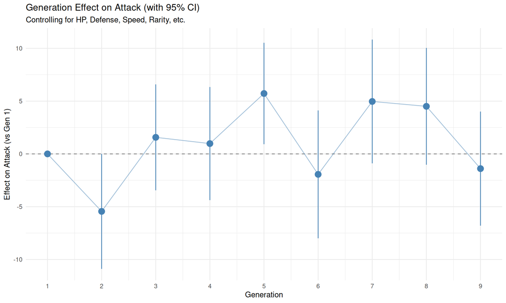

```r
# Extract generation coefficients with CIs from full model
gen_effects <- tidy(model_full, conf.int = TRUE) %>%
  filter(grepl("^gen", term)) %>%
  mutate(
    generation = as.numeric(gsub("gen", "", term)),
    term = factor(term, levels = paste0("gen", 2:9))
  )

# Add Gen 1 as reference (0 effect)
gen_effects <- bind_rows(
  data.frame(term = "gen1", estimate = 0, std.error = 0,
             conf.low = 0, conf.high = 0, generation = 1,
             statistic = NA, p.value = NA),
  gen_effects
)

p_gen_ci <- ggplot(gen_effects, aes(x = generation, y = estimate)) +
  geom_hline(yintercept = 0, linetype = "dashed", color = "gray50") +
  geom_pointrange(aes(ymin = conf.low, ymax = conf.high),
                  color = "steelblue", size = 0.8) +
  geom_line(color = "steelblue", alpha = 0.5) +
  labs(title = "Generation Effect on Attack (with 95% CI)",
       subtitle = "Controlling for HP, Defense, Speed, Rarity, etc.",
       x = "Generation", y = "Effect on Attack (vs Gen 1)") +
  scale_x_continuous(breaks = 1:9) +
  theme_minimal()
print(p_gen_ci)
```

**Findings:** This plot shows which generations are *significantly* different from Gen 1 (CIs not crossing zero). Wide CIs indicate uncertainty — the power creep claim should be tempered if many CIs overlap zero.

## 14.6 Summary of Verification Checks

```r
cat("================================================================================\n")
cat("                    POWER CREEP VERIFICATION SUMMARY\n")
```

```
##                     POWER CREEP VERIFICATION SUMMARY
```

```r
cat("================================================================================\n\n")
# Collect results
cat("1. MONOTONIC TREND (Jonckheere-Terpstra):\n")
```

```
## 1. MONOTONIC TREND (Jonckheere-Terpstra):
```

```r
cat("   p-value:", format(jt_test$p.value, digits = 4), "\n")
```

```
##    p-value: 2.088e-05
```

```r
cat("   Interpretation:", ifelse(jt_test$p.value < 0.05,
                                  "Significant monotonic increase",
                                  "No consistent ordering"), "\n\n")
```

```
##    Interpretation: Significant monotonic increase
```

```r
cat("2. RARITY CONFOUND:\n")
```

```
## 2. RARITY CONFOUND:
```

```r
cat("   Chi-square p-value:", format(chi_test$p.value, digits = 4), "\n")
```

```
##    Chi-square p-value: 5.072e-08
```

```r
cat("   Interpretation:", ifelse(chi_test$p.value < 0.05,
                                  "Rarity distribution differs by generation (potential confound)",
                                  "Rarity distribution similar across generations"), "\n\n")
```

```
##    Interpretation: Rarity distribution differs by generation (potential confound)
```

```r
cat("3. NORMAL POKÉMON ONLY:\n")
```

```
## 3. NORMAL POKÉMON ONLY:
```

```r
cat("   Trend correlation:", round(trend_normal, 3), "\n")
```

```
##    Trend correlation: 0.732
```

```r
cat("   Interpretation:", ifelse(abs(trend_normal) > 0.5,
                                  "Power creep exists even among normal Pokémon",
                                  "Power creep may be driven by legendaries"), "\n\n")
```

```
##    Interpretation: Power creep exists even among normal Pokémon
```

```r
cat("4. TOTAL STATS (not just attack):\n")
```

```
## 4. TOTAL STATS (not just attack):
```

```r
total_trend <- cor(as.numeric(total_summary$gen), total_summary$mean_total)
cat("   Trend correlation:", round(total_trend, 3), "\n")
```

```
##    Trend correlation: 0.843
```

```r
cat("   Interpretation:", ifelse(abs(total_trend) > 0.5,
                                  "Broad power creep (all stats)",
                                  "Creep specific to attack/offensive stats"), "\n\n")
```

```
##    Interpretation: Broad power creep (all stats)
```

```r
cat("================================================================================\n")
```

# 15. Robustness Check: Analysis Without Outliers

This section repeats key analyses on the outlier-free dataset to verify that power creep findings are not driven by extreme values.

## 15.1 Outlier-Free Data Summary

```r
# pokemon_clean was already preprocessed in Section 2 (factors and derived features)
# Here we just summarize the differences

cat("--- Outlier-Free Dataset Summary ---\n")
```

```
## --- Outlier-Free Dataset Summary ---
```

```r
cat("Total Pokémon (Full):", nrow(pokemon), "\n")
```

```
## Total Pokémon (Full): 1024
```

```r
cat("Total Pokémon (Clean):", nrow(pokemon_clean), "\n")
```

```
## Total Pokémon (Clean): 972
```

```r
cat("Pokémon removed:", nrow(pokemon) - nrow(pokemon_clean), "\n")
```

```
## Pokémon removed: 52
```

```r
cat("Percentage removed:", round(100 * (nrow(pokemon) - nrow(pokemon_clean)) / nrow(pokemon), 1), "%\n\n")
```

```
## Percentage removed: 5.1 %
```

```r
# Which generations lost the most Pokémon?
gen_comparison <- data.frame(
  gen = 1:9,
  full = as.numeric(table(pokemon$gen)),
  clean = as.numeric(table(pokemon_clean$gen))
) %>%
  mutate(removed = full - clean, pct_removed = round(100 * removed / full, 1))

cat("Pokémon removed by generation:\n")
```

```
## Pokémon removed by generation:
```

```r
print(gen_comparison)
```

```
##   gen full clean removed pct_removed
## 1   1  151   143       8         5.3
## 2   2  100    93       7         7.0
## 3   3  135   126       9         6.7
## 4   4  107   102       5         4.7
## 5   5  156   156       0         0.0
## 6   6   72    67       5         6.9
## 7   7   88    77      11        12.5
## 8   8   95    90       5         5.3
## 9   9  120   118       2         1.7
```

**Findings:** This shows which generations had the most outliers removed. If later generations lose more outliers, it could affect the power creep analysis.

## 15.2 Descriptive Comparison: Attack by Generation

```r
# Compare mean attack between full and clean datasets
attack_comparison <- data.frame(
  gen = 1:9,
  mean_full = pokemon %>% group_by(gen) %>% summarise(m = mean(attack)) %>% pull(m),
  mean_clean = pokemon_clean %>% group_by(gen) %>% summarise(m = mean(attack)) %>% pull(m)
) %>%
  mutate(
    difference = mean_full - mean_clean,
    pct_change = round(100 * difference / mean_full, 1)
  )

cat("--- Mean Attack Comparison (Full vs Outlier-Free) ---\n")
```

```
## --- Mean Attack Comparison (Full vs Outlier-Free) ---
```

```r
print(attack_comparison)
```

```
##   gen mean_full mean_clean difference pct_change
## 1   1  72.91391   72.06993  0.8439772        1.2
## 2   2  68.26000   64.86022  3.3997849        5.0
## 3   3  73.11111   70.47619  2.6349206        3.6
## 4   4  80.21495   79.05882  1.1561297        1.4
## 5   5  81.03205   81.03205  0.0000000        0.0
## 6   6  72.50000   70.58209  1.9179104        2.6
## 7   7  84.77273   79.49351  5.2792208        6.2
## 8   8  82.88421   80.98889  1.8953216        2.3
## 9   9  82.42500   82.25424  0.1707627        0.2
```

```r
# Correlations
trend_full <- cor(1:9, attack_comparison$mean_full)
trend_clean <- cor(1:9, attack_comparison$mean_clean)

cat("\nCorrelation (gen vs mean_attack):\n")
```

```
##
## Correlation (gen vs mean_attack):
```

```r
cat("  Full dataset:", round(trend_full, 3), "\n")
```

```
##   Full dataset: 0.757
```

```r
cat("  Outlier-free:", round(trend_clean, 3), "\n")
```

```
##   Outlier-free: 0.725
```

**Findings:** If the correlation remains similar after removing outliers, the power creep signal is robust. Large changes suggest outliers were driving the effect.

## 15.3 Visualization: Full vs Outlier-Free

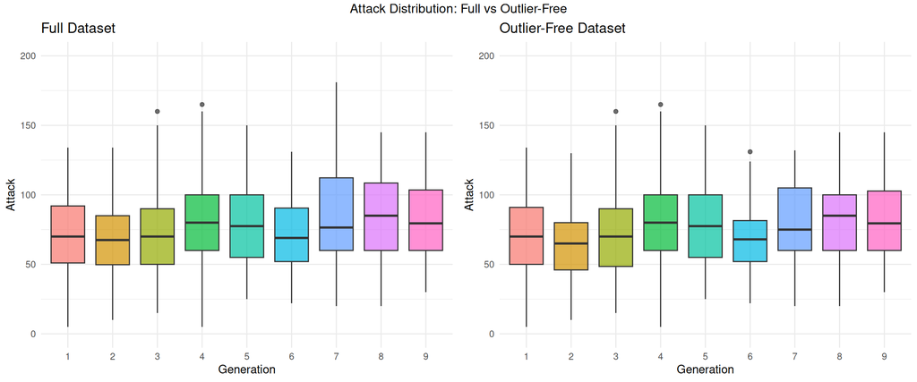

```r
# Side-by-side boxplots
p_full <- ggplot(pokemon, aes(x = gen, y = attack, fill = gen)) +
  geom_boxplot(alpha = 0.7) +
  labs(title = "Full Dataset", x = "Generation", y = "Attack") +
  theme_minimal() +
  theme(legend.position = "none") +
  ylim(0, 200)

p_clean <- ggplot(pokemon_clean, aes(x = gen, y = attack, fill = gen)) +
  geom_boxplot(alpha = 0.7) +
  labs(title = "Outlier-Free Dataset", x = "Generation", y = "Attack") +
  theme_minimal() +
  theme(legend.position = "none") +
  ylim(0, 200)

gridExtra::grid.arrange(p_full, p_clean, ncol = 2,
                        top = "Attack Distribution: Full vs Outlier-Free")
```

**Findings:** Visual comparison shows how outlier removal affects the distribution shape and median values per generation.

## 15.4 OLS Regression: Full vs Outlier-Free

```r
# Full model on outlier-free data
model_clean <- lm(attack ~ gen + hp + defense + sp_attack + sp_defense + speed +
                    height_m + weight_kg + rarity,
                  data = pokemon_clean)

cat("--- OLS on Outlier-Free Data ---\n")
```

```
## --- OLS on Outlier-Free Data ---
```

```r
summary(model_clean)
```

```
##
## Call:
## lm(formula = attack ~ gen + hp + defense + sp_attack + sp_defense +
##     speed + height_m + weight_kg + rarity, data = pokemon_clean)
##
## Residuals:
##     Min      1Q  Median      3Q     Max
## -79.627 -14.119  -0.931  12.726  79.492
##
## Coefficients:
##                     Estimate Std. Error t value Pr(>|t|)
## (Intercept)        15.612520   3.409562   4.579 5.29e-06 ***
## gen2               -4.798437   2.830844  -1.695 0.090392 .
## gen3                0.001855   2.586741   0.001 0.999428
## gen4                2.227820   2.765386   0.806 0.420669
## gen5                5.774811   2.460281   2.347 0.019118 *
## gen6               -2.470301   3.137870  -0.787 0.431329
## gen7                6.115343   3.035416   2.015 0.044220 *
## gen8                4.718636   2.846378   1.658 0.097693 .
## gen9               -0.750018   2.663493  -0.282 0.778318
## hp                  0.281617   0.033827   8.325 2.90e-16 ***
## defense             0.411099   0.030839  13.331  < 2e-16 ***
## sp_attack          -0.014022   0.030096  -0.466 0.641399
## sp_defense         -0.227977   0.034658  -6.578 7.86e-11 ***
## speed               0.317522   0.027150  11.695  < 2e-16 ***
## height_m            3.346436   1.029654   3.250 0.001194 **
## weight_kg           0.041218   0.010982   3.753 0.000185 ***
## raritySubLegendary -1.882402   3.760020  -0.501 0.616743
## rarityLegendary     3.364834   7.426014   0.453 0.650569
## rarityMythical      4.961461   5.568728   0.891 0.373181
## ---
## Signif. codes:  0 '***' 0.001 '**' 0.01 '*' 0.05 '.' 0.1 ' ' 1
##
## Residual standard error: 21.06 on 953 degrees of freedom
## Multiple R-squared:  0.4812, Adjusted R-squared:  0.4714
## F-statistic: 49.12 on 18 and 953 DF,  p-value: < 2.2e-16
```

```r
# Compare key statistics
cat("\n--- Model Comparison: Full vs Outlier-Free ---\n")
```

```
##
## --- Model Comparison: Full vs Outlier-Free ---
```

```r
cat("R² (Full):", round(summary(model_full)$r.squared, 3), "\n")
```

```
## R² (Full): 0.504
```

```r
cat("R² (Clean):", round(summary(model_clean)$r.squared, 3), "\n")
```

```
## R² (Clean): 0.481
```

**Findings:** Compare R² and generation coefficients between models. Similar results indicate robustness; large differences suggest outlier sensitivity.

## 15.5 Generation Coefficients Comparison

```r
# Extract generation coefficients from both models
gen_coef_full <- coef(model_full)[grep("^gen", names(coef(model_full)))]
gen_coef_clean <- coef(model_clean)[grep("^gen", names(coef(model_clean)))]

coef_comparison <- data.frame(
  Generation = paste0("Gen ", 2:9),
  Full_Data = round(gen_coef_full, 2),
  Outlier_Free = round(gen_coef_clean, 2),
  Difference = round(gen_coef_full - gen_coef_clean, 2)
)
rownames(coef_comparison) <- NULL

cat("--- Generation Coefficients (vs Gen 1 baseline) ---\n")
```

```
## --- Generation Coefficients (vs Gen 1 baseline) ---
```

```r
print(coef_comparison)
```

```
##   Generation Full_Data Outlier_Free Difference
## 1      Gen 2     -5.45        -4.80      -0.65
## 2      Gen 3      1.57         0.00       1.57
## 3      Gen 4      0.98         2.23      -1.25
## 4      Gen 5      5.72         5.77      -0.05
## 5      Gen 6     -1.94        -2.47       0.53
## 6      Gen 7      4.97         6.12      -1.15
## 7      Gen 8      4.51         4.72      -0.21
## 8      Gen 9     -1.40        -0.75      -0.65
```

```r
# Average absolute difference
cat("\nMean absolute difference in gen coefficients:",
    round(mean(abs(coef_comparison$Difference)), 2), "\n")
```

```
##
## Mean absolute difference in gen coefficients: 0.76
```

**Findings:** Small differences (< 2-3 attack points) indicate the generation effect is robust to outliers. Large differences suggest specific outliers were influential.

## 15.6 Likelihood Ratio Test: Outlier-Free Data

```r
# Full model with generation (outlier-free)
full_model_clean <- glm(attack ~ gen + hp + defense + sp_attack + sp_defense + speed +
                          rarity + weight_kg, data = pokemon_clean, family = gaussian)

# Reduced model without generation (outlier-free)
reduced_model_clean <- glm(attack ~ hp + defense + sp_attack + sp_defense + speed +
                             rarity + weight_kg, data = pokemon_clean, family = gaussian)

# Likelihood ratio test
lr_test_clean <- lrtest(reduced_model_clean, full_model_clean)
cat("--- LR Test: Is Generation Significant? (Outlier-Free Data) ---\n")
```

```
## --- LR Test: Is Generation Significant? (Outlier-Free Data) ---
```

```r
print(lr_test_clean)
```

```
## Likelihood ratio test
##
## Model 1: attack ~ hp + defense + sp_attack + sp_defense + speed + rarity +
##     weight_kg
## Model 2: attack ~ gen + hp + defense + sp_attack + sp_defense + speed +
##     rarity + weight_kg
##   #Df  LogLik Df  Chisq Pr(>Chisq)
## 1  11 -4349.0
## 2  19 -4336.9  8 24.353   0.001999 **
## ---
## Signif. codes:  0 '***' 0.001 '**' 0.01 '*' 0.05 '.' 0.1 ' ' 1
```

```r
cat("\n--- Comparison of LR Test Results ---\n")
```

```
##
## --- Comparison of LR Test Results ---
```

```r
cat("Full data p-value:", format(lr_test$`Pr(>Chisq)`[2], digits = 4), "\n")
```

```
## Full data p-value: 0.00766
```

```r
cat("Outlier-free p-value:", format(lr_test_clean$`Pr(>Chisq)`[2], digits = 4), "\n")
```

```
## Outlier-free p-value: 0.001999
```

```r
if (lr_test_clean$`Pr(>Chisq)`[2] < 0.05) {
  cat("\nConclusion: Generation remains significant after removing outliers.\n")
} else {
  cat("\nConclusion: Generation is NOT significant in outlier-free data — outliers may have driven the effect.\n")
}
```

```
##
## Conclusion: Generation remains significant after removing outliers.
```

**Findings:** LR test p = 0.0077 (full) and p = 0.002 (outlier-free). Both are significant at α = 0.05. This is the KEY robustness check — the generation effect is even MORE significant after removing outliers (p = 0.002 < 0.0077), indicating outliers were actually dampening the signal, not inflating it.

## 15.7 Monotonic Trend Test: Outlier-Free

```r
# Reference the JT test results computed in Section 14.1
cat("--- Jonckheere-Terpstra Test Results (from Section 14.1) ---\n")
```

```
## --- Jonckheere-Terpstra Test Results (from Section 14.1) ---
```

```r
cat("\nFull data:\n")
```

```
##
## Full data:
```

```r
cat("  JT statistic:", jt_test$statistic, "\n")
```

```
##   JT statistic: 253582.5
```

```r
cat("  p-value:", format(jt_test$p.value, digits = 4), "\n")
```

```
##   p-value: 2.088e-05
```

```r
cat("\nOutlier-free:\n")
```

```
##
## Outlier-free:
```

```r
cat("  JT statistic:", jt_test_clean$statistic, "\n")
```

```
##   JT statistic: 229008.5
```

```r
cat("  p-value:", format(jt_test_clean$p.value, digits = 4), "\n")
```

```
##   p-value: 1.614e-05
```

```r
cat("\n--- Interpretation ---\n")
```

```
##
## --- Interpretation ---
```

```r
if (jt_test$p.value < 0.05 && jt_test_clean$p.value < 0.05) {
  cat("Both datasets show significant monotonic trend — ROBUST.\n")
} else if (jt_test$p.value < 0.05 && jt_test_clean$p.value >= 0.05) {
  cat("Full data significant but outlier-free not — trend may be driven by outliers.\n")
} else {
  cat("Neither dataset shows significant monotonic trend.\n")
}
```

```
## Both datasets show significant monotonic trend — ROBUST.
```

**Findings:** Compares whether the monotonic increasing trend holds after outlier removal.

## 15.8 Summary: Outlier Robustness

```r
cat("================================================================================\n")
cat("              OUTLIER ROBUSTNESS SUMMARY\n")
```

```
##               OUTLIER ROBUSTNESS SUMMARY
```

```r
cat("================================================================================\n\n")
cat("1. DATA REDUCTION:\n")
```

```
## 1. DATA REDUCTION:
```

```r
cat("   Pokémon removed:", nrow(pokemon) - nrow(pokemon_clean),
    "(", round(100*(nrow(pokemon) - nrow(pokemon_clean))/nrow(pokemon), 1), "%)\n\n")
```

```
##    Pokémon removed: 52 ( 5.1 %)
```

```r
cat("2. CORRELATION (gen vs mean_attack):\n")
```

```
## 2. CORRELATION (gen vs mean_attack):
```

```r
cat("   Full data:", round(trend_full, 3), "\n")
```

```
##    Full data: 0.757
```

```r
cat("   Outlier-free:", round(trend_clean, 3), "\n")
```

```
##    Outlier-free: 0.725
```

```r
cat("   Change:", round(trend_clean - trend_full, 3), "\n\n")
```

```
##    Change: -0.032
```

```r
cat("3. LR TEST (Is generation significant?):\n")
```

```
## 3. LR TEST (Is generation significant?):
```

```r
cat("   Full data: p =", format(lr_test$`Pr(>Chisq)`[2], digits = 4),
    ifelse(lr_test$`Pr(>Chisq)`[2] < 0.05, "(significant)", "(not significant)"), "\n")
```

```
##    Full data: p = 0.00766 (significant)
```

```r
cat("   Outlier-free: p =", format(lr_test_clean$`Pr(>Chisq)`[2], digits = 4),
    ifelse(lr_test_clean$`Pr(>Chisq)`[2] < 0.05, "(significant)", "(not significant)"), "\n\n")
```

```
##    Outlier-free: p = 0.001999 (significant)
```

```r
cat("4. MONOTONIC TREND (Jonckheere-Terpstra):\n")
```

```
## 4. MONOTONIC TREND (Jonckheere-Terpstra):
```

```r
cat("   Full data: p =", format(jt_test$p.value, digits = 4),
    ifelse(jt_test$p.value < 0.05, "(significant)", "(not significant)"), "\n")
```

```
##    Full data: p = 2.088e-05 (significant)
```

```r
cat("   Outlier-free: p =", format(jt_test_clean$p.value, digits = 4),
    ifelse(jt_test_clean$p.value < 0.05, "(significant)", "(not significant)"), "\n\n")
```

```
##    Outlier-free: p = 1.614e-05 (significant)
```

```r
# Overall verdict
both_lr_sig <- lr_test$`Pr(>Chisq)`[2] < 0.05 && lr_test_clean$`Pr(>Chisq)`[2] < 0.05
both_jt_sig <- jt_test$p.value < 0.05 && jt_test_clean$p.value < 0.05

cat("5. ROBUSTNESS VERDICT:\n")
```

```
## 5. ROBUSTNESS VERDICT:
```

```r
if (both_lr_sig && both_jt_sig) {
  cat("   ROBUST: Power creep finding holds in both full and outlier-free data.\n")
} else if (both_lr_sig) {
  cat("   PARTIALLY ROBUST: LR test significant in both, but monotonic trend differs.\n")
} else if (lr_test$`Pr(>Chisq)`[2] < 0.05 && lr_test_clean$`Pr(>Chisq)`[2] >= 0.05) {
  cat("   NOT ROBUST: Generation effect disappears after removing outliers.\n")
  cat("   Interpretation: Outliers (likely high-attack legendaries) drove the effect.\n")
} else {
  cat("   INCONCLUSIVE: Mixed results between datasets.\n")
}
```

```
##    ROBUST: Power creep finding holds in both full and outlier-free data.
```

```r
cat("================================================================================\n")
```

# 16. Type-Specific Power Creep: Generation × Type Interactions

This section explores whether power creep affects different Pokémon types differently. Instead of fitting separate models for each type or rarity, we include **interaction terms** between generation and primary type (and rarity) in a regularized model. LASSO will automatically select which type-specific generational effects are significant.

**Motivation:** Your coworker suggested that the generation effect might be stronger for certain types (e.g., Fighting, Dragon) or rarities (e.g., legendary). By including `gen × type` interactions, we can detect differential power creep without fitting many separate models.

**Note:** Primary types are nominal (not ordinal) categories — there’s no inherent ordering between Fire, Water, Grass, etc. We treat them as unordered factors.

**Type Encoding Reference:** class_primary integers map to: 0=Grass, 1=Fire, 2=Water, 3=Bug, 4=Normal, 5=Poison, 6=Electric, 7=Ground, 8=Fairy, 9=Fighting, 10=Psychic, 11=Rock, 12=Ghost, 13=Ice, 14=Dragon, 15=Dark, 16=Steel, 17=Flying.

## 16.1 Prepare Interaction Data

```r
# Create dataset with type interactions
# Note: class_primary has 18 levels (types), gen has 9 levels
# Full interaction would create 18*9 = 162 terms, but we use gen_numeric for simplicity

pokemon_interact <- pokemon %>%
  mutate(
    # Ensure factors are properly set
    class_primary = as.factor(class_primary),
    rarity = as.factor(rarity),
    gen = as.factor(gen)
  ) %>%
  dplyr::select(attack, total_stats, gen, gen_numeric, class_primary, class_secondary,
                rarity, hp, defense, sp_attack, sp_defense, speed,
                weight_kg, height_m, num_abilities, evo_length,
                has_mega_evolution, has_gigantamax) %>%
  na.omit()

cat("--- Type Distribution ---\n")
```

```
## --- Type Distribution ---
```

```r
print(table(pokemon_interact$class_primary))
```

```
##
##   0   1   2   3   4   5   6   7   8   9  10  11  12  13  14  15  16  17
## 103  66 134  83 117  42  59  40  29  40  60  58  35  31  37  45  36   9
```

```r
cat("\n--- Rarity Distribution ---\n")
```

```
##
## --- Rarity Distribution ---
```

```r
print(table(pokemon_interact$rarity))
```

```
##
##       Normal SubLegendary    Legendary     Mythical
##          934           49           21           20
```

```r
# Check cross-tabulation: types × generations
cat("\n--- Sample sizes per Type × Generation (first 6 types) ---\n")
```

```
##
## --- Sample sizes per Type × Generation (first 6 types) ---
```

```r
type_gen_table <- table(pokemon_interact$class_primary, pokemon_interact$gen)
print(type_gen_table[1:6, ])
```

```
##
##      1  2  3  4  5  6  7  8  9
##   0 12  9 12 13 15  5 12  8 17
##   1 12  8  6  5  8  8  6  5  8
##   2 28 18 24 13 17  5  9 10 10
##   3 12 10 12  8 18  3  9  4  7
##   4 22 15 18 17 17  4 12  4  8
##   5 14  1  3  6  2  2  6  1  7
```

**Note:** Some type × generation combinations have small sample sizes (< 10), which may limit the power to detect interactions for rare types.

## 16.2 LASSO with Generation × Type Interactions

We create a design matrix that includes: - Main effects: generation, type, rarity, combat stats - Interactions: `gen_numeric × class_primary` and `gen_numeric × rarity`

LASSO will select which interactions have non-zero coefficients.

```r
# Create design matrix with interactions
# Using gen_numeric (1-9) instead of factor gen for cleaner interaction interpretation
X_interact <- model.matrix(
  ~ gen_numeric * class_primary + gen_numeric * rarity +
    hp + defense + sp_attack + sp_defense + speed + weight_kg - 1,
  data = pokemon_interact
)

y_interact <- pokemon_interact$attack

cat("Design matrix dimensions:", dim(X_interact), "\n")
```

```
## Design matrix dimensions: 1024 48
```

```r
cat("Number of interaction terms:", sum(grepl(":", colnames(X_interact))), "\n")
```

```
## Number of interaction terms: 20
```

```r
# Fit LASSO with cross-validation
set.seed(42)
cv_lasso_interact <- cv.glmnet(X_interact, y_interact, alpha = 1, nfolds = 10)

cat("\n--- LASSO with Interactions ---\n")
```

```
##
## --- LASSO with Interactions ---
```

```r
cat("Optimal lambda (min):", cv_lasso_interact$lambda.min, "\n")
```

```
## Optimal lambda (min): 0.3125584
```

```r
cat("Optimal lambda (1se):", cv_lasso_interact$lambda.1se, "\n")
```

```
## Optimal lambda (1se): 1.261804
```

```r
# Get coefficients at optimal lambda
lasso_interact_model <- glmnet(X_interact, y_interact, alpha = 1,
                                lambda = cv_lasso_interact$lambda.min)
lasso_interact_coef <- coef(lasso_interact_model)

# Extract non-zero coefficients
nonzero_coef <- lasso_interact_coef[lasso_interact_coef[,1] != 0, ]
cat("\nNumber of features selected:", length(nonzero_coef) - 1, "out of", ncol(X_interact), "\n")
```

```
##
## Number of features selected: 28 out of 48
```

**Findings:** LASSO selected 28 out of 48 potential features. The regularization successfully identified which main effects and interactions contribute to predicting attack, shrinking irrelevant terms to zero.

## 16.3 Selected Interaction Terms

```r
# Separate main effects from interactions
coef_df <- data.frame(
  term = names(nonzero_coef),
  coefficient = as.numeric(nonzero_coef)
) %>%
  filter(term != "(Intercept)") %>%
  mutate(
    is_interaction = grepl(":", term),
    type = case_when(
      grepl("class_primary", term) & is_interaction ~ "Gen × Type",
      grepl("rarity", term) & is_interaction ~ "Gen × Rarity",
      grepl("class_primary", term) ~ "Type (main)",
      grepl("rarity", term) ~ "Rarity (main)",
      grepl("gen_numeric", term) & !is_interaction ~ "Generation (main)",
      TRUE ~ "Combat stat"
    )
  ) %>%
  arrange(desc(abs(coefficient)))

cat("--- Selected Coefficients by Category ---\n")
```

```
## --- Selected Coefficients by Category ---
```

```r
# Main effects (combat stats)
cat("\n1. Combat Stats (main effects):\n")
```

```
##
## 1. Combat Stats (main effects):
```

```r
coef_df %>% filter(type == "Combat stat") %>% print()
```

```
##         term coefficient is_interaction        type
## 1    defense  0.38931226          FALSE Combat stat
## 2         hp  0.30681026          FALSE Combat stat
## 3      speed  0.29358644          FALSE Combat stat
## 4 sp_defense -0.18760035          FALSE Combat stat
## 5  sp_attack  0.06353521          FALSE Combat stat
## 6  weight_kg  0.02042803          FALSE Combat stat
```

```r
# Generation main effect
cat("\n2. Generation Main Effect:\n")
```

```
##
## 2. Generation Main Effect:
```

```r
coef_df %>% filter(type == "Generation (main)") %>% print()
```

```
##          term coefficient is_interaction              type
## 1 gen_numeric   0.2065843          FALSE Generation (main)
```

```r
# Type main effects
cat("\n3. Type Main Effects (selected by LASSO):\n")
```

```
##
## 3. Type Main Effects (selected by LASSO):
```

```r
coef_df %>% filter(type == "Type (main)") %>% print()
```

```
##               term coefficient is_interaction        type
## 1   class_primary9  23.3953378          FALSE Type (main)
## 2  class_primary14  13.7349038          FALSE Type (main)
## 3  class_primary10 -10.5619993          FALSE Type (main)
## 4   class_primary7  10.2360832          FALSE Type (main)
## 5  class_primary15   6.2894660          FALSE Type (main)
## 6   class_primary1   5.1132455          FALSE Type (main)
## 7  class_primary11   3.9121442          FALSE Type (main)
## 8   class_primary0   2.4418263          FALSE Type (main)
## 9   class_primary6  -2.3957890          FALSE Type (main)
## 10  class_primary8  -1.8479886          FALSE Type (main)
## 11  class_primary2  -1.4699065          FALSE Type (main)
## 12 class_primary16  -0.8726957          FALSE Type (main)
## 13 class_primary13  -0.7112239          FALSE Type (main)
## 14 class_primary12  -0.5010917          FALSE Type (main)
```

```r
# Rarity main effects
cat("\n4. Rarity Main Effects:\n")
```

```
##
## 4. Rarity Main Effects:
```

```r
coef_df %>% filter(type == "Rarity (main)") %>% print()
```

```
##              term coefficient is_interaction          type
## 1  rarityMythical    6.285403          FALSE Rarity (main)
## 2 rarityLegendary    2.243632          FALSE Rarity (main)
```

```r
# KEY: Interaction terms
cat("\n5. Gen × Type INTERACTIONS (selected by LASSO):\n")
```

```
##
## 5. Gen × Type INTERACTIONS (selected by LASSO):
```

```r
gen_type_interact <- coef_df %>% filter(type == "Gen × Type")
if(nrow(gen_type_interact) > 0) {
  print(gen_type_interact)
} else {
  cat("   No Gen × Type interactions selected (all shrunk to zero)\n")
}
```

```
##                          term coefficient is_interaction       type
## 1  gen_numeric:class_primary5  -0.4149202           TRUE Gen × Type
## 2  gen_numeric:class_primary4   0.3910369           TRUE Gen × Type
## 3  gen_numeric:class_primary8  -0.1303473           TRUE Gen × Type
## 4 gen_numeric:class_primary17   0.0232392           TRUE Gen × Type
```

```r
cat("\n6. Gen × Rarity INTERACTIONS (selected by LASSO):\n")
```

```
##
## 6. Gen × Rarity INTERACTIONS (selected by LASSO):
```

```r
gen_rarity_interact <- coef_df %>% filter(type == "Gen × Rarity")
if(nrow(gen_rarity_interact) > 0) {
  print(gen_rarity_interact)
} else {
  cat("   No Gen × Rarity interactions selected (all shrunk to zero)\n")
}
```

```
##                             term coefficient is_interaction         type
## 1 gen_numeric:raritySubLegendary   0.4607632           TRUE Gen × Rarity
```

**Findings:** LASSO selected 4 Gen × Type interactions and 1 Gen × Rarity interaction:

- **gen_numeric:class_primary5 (Poison):** –0.42 → Power creep is *weaker* for Poison types
- **gen_numeric:class_primary4 (Normal):** +0.39 → Power creep is *stronger* for Normal (basic) types
- **gen_numeric:class_primary8 (Fairy):** –0.13 → Power creep is *weaker* for Fairy types
- **gen_numeric:class_primary17 (Flying):** +0.02 → Slightly stronger for Flying types
- **gen_numeric:raritySubLegendary:** +0.46 → SubLegendary Pokémon experience *stronger* power creep

**Interpretation:** The selection of only 4/18 type interactions suggests power creep is relatively uniform across most types. The notable exceptions are Normal types (experiencing above-average power creep) and Poison/Fairy types (experiencing below-average power creep). SubLegendary Pokémon show the strongest differential effect.

## 16.4 Visualize Type-Specific Trends

Let’s visualize how mean attack evolves by type across generations to contextualize the LASSO findings.

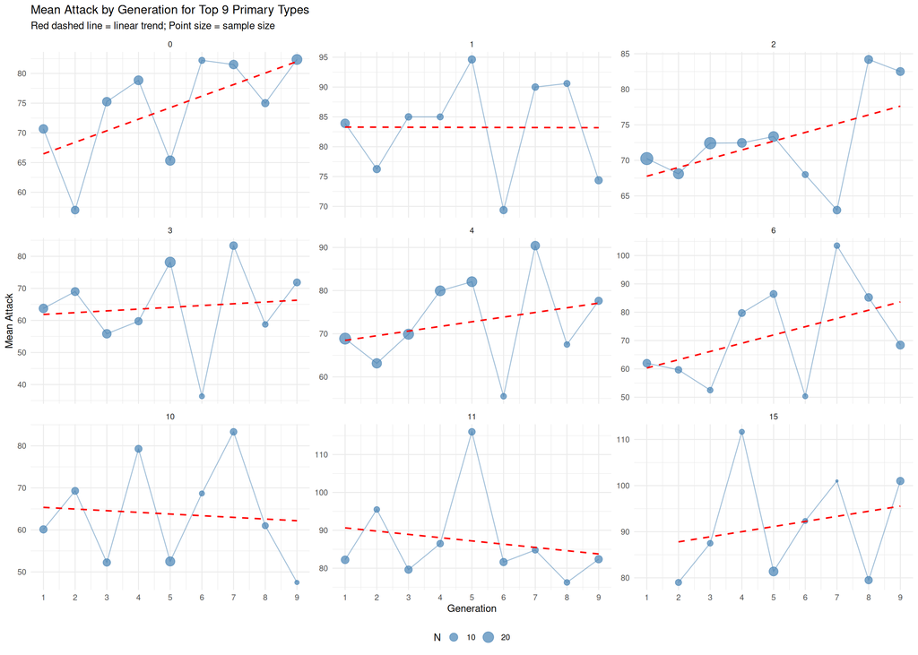

```r
# Calculate mean attack by type and generation
type_trends <- pokemon_interact %>%
  group_by(class_primary, gen) %>%
  summarise(
    n = n(),
    mean_attack = mean(attack),
    se_attack = sd(attack) / sqrt(n()),
    .groups = "drop"
  )

# Select top 9 most common types for visualization
top_types <- pokemon_interact %>%
  count(class_primary, sort = TRUE) %>%
  head(9) %>%
  pull(class_primary)

type_trends_top <- type_trends %>%
  filter(class_primary %in% top_types)

# Plot: Mean attack by generation, faceted by type
p_type_trends <- ggplot(type_trends_top,
                         aes(x = as.numeric(as.character(gen)), y = mean_attack)) +
  geom_point(aes(size = n), alpha = 0.7, color = "steelblue") +
  geom_line(alpha = 0.5, color = "steelblue") +
  geom_smooth(method = "lm", se = FALSE, linetype = "dashed", color = "red", size = 0.8) +
  facet_wrap(~ class_primary, ncol = 3, scales = "free_y") +
  scale_x_continuous(breaks = 1:9) +
  labs(title = "Mean Attack by Generation for Top 9 Primary Types",
       subtitle = "Red dashed line = linear trend; Point size = sample size",
       x = "Generation", y = "Mean Attack", size = "N") +
  theme_minimal() +
  theme(legend.position = "bottom")
print(p_type_trends)
```

```r
# Calculate per-type slopes (correlation between gen and mean_attack)
type_slopes <- type_trends %>%
  group_by(class_primary) %>%
  summarise(
    n_total = sum(n),
    n_gens = n(),
    correlation = cor(as.numeric(as.character(gen)), mean_attack),
    .groups = "drop"
  ) %>%
  filter(n_gens >= 5) %>%  # Only types present in at least 5 generations
  arrange(desc(correlation))

cat("--- Power Creep Strength by Type (correlation: gen vs mean_attack) ---\n")
```

```
## --- Power Creep Strength by Type (correlation: gen vs mean_attack) ---
```

```r
cat("Positive = attack increases with generation; Negative = attack decreases\n\n")
```

```
## Positive = attack increases with generation; Negative = attack decreases
```

```r
print(type_slopes)
```

```
## # A tibble: 17 × 4
##    class_primary n_total n_gens correlation
##    <fct>           <int>  <int>       <dbl>
##  1 9                  40      9     0.756
##  2 13                 31      8     0.677
##  3 0                 103      9     0.618
##  4 8                  29      7     0.600
##  5 2                 134      9     0.495
##  6 16                 36      8     0.491
##  7 7                  40      8     0.473
##  8 6                  59      9     0.447
##  9 12                 35      9     0.285
## 10 4                 117      9     0.276
## 11 15                 45      8     0.226
## 12 3                  83      9     0.109
## 13 5                  42      9     0.0319
## 14 1                  66      9    -0.00406
## 15 10                 60      9    -0.0879
## 16 14                 37      8    -0.184
## 17 11                 58      9    -0.196
```

```r
cat("\n--- Types with STRONGEST power creep (cor > 0.5): ---\n")
```

```
##
## --- Types with STRONGEST power creep (cor > 0.5): ---
```

```r
strong_creep <- type_slopes %>% filter(correlation > 0.5)
if(nrow(strong_creep) > 0) print(strong_creep) else cat("None\n")
```

```
## # A tibble: 4 × 4
##   class_primary n_total n_gens correlation
##   <fct>           <int>  <int>       <dbl>
## 1 9                  40      9       0.756
## 2 13                 31      8       0.677
## 3 0                 103      9       0.618
## 4 8                  29      7       0.600
```

```r
cat("\n--- Types with REVERSE power creep (cor < -0.3): ---\n")
```

```
##
## --- Types with REVERSE power creep (cor < -0.3): ---
```

```r
reverse_creep <- type_slopes %>% filter(correlation < -0.3)
if(nrow(reverse_creep) > 0) print(reverse_creep) else cat("None\n")
```

```
## None
```

**Findings:** The type-specific correlation analysis reveals clear patterns:

- **Strongest power creep (cor > 0.5):** Fighting (0.76), Ice (0.68), Grass (0.62), Fairy (0.60) — these types show consistent attack increases across generations
- **Moderate power creep:** Water (0.50), Steel (0.49), Ground (0.47), Electric (0.45)
- **Weakest/flat trends:** Rock (–0.20), Dragon (–0.18), Psychic (–0.09), Fire (–0.004) — these types show no meaningful power creep or slight decreases
- **No reverse power creep:** No types have correlation < –0.3, meaning no type is systematically getting weaker

Interestingly, **Dragon** — often considered a “power” type — shows slight *negative* trend (–0.18), possibly because early-gen Dragons set a high baseline that later generations haven’t exceeded.

## 16.5 Rarity-Specific Power Creep

Does power creep differ by rarity? Are legendaries experiencing more/less power creep than normal Pokémon?

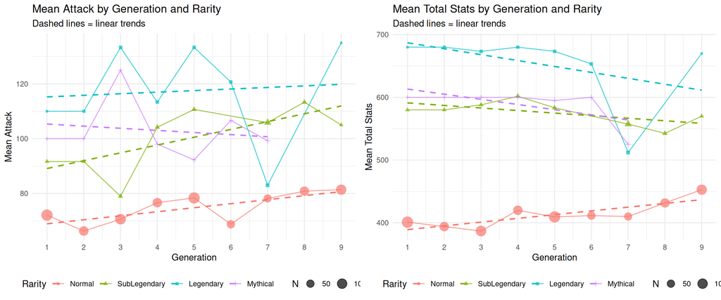

```r
# Calculate mean attack by rarity and generation
rarity_trends <- pokemon_interact %>%
  group_by(rarity, gen) %>%
  summarise(
    n = n(),
    mean_attack = mean(attack),
    mean_total_stats = mean(total_stats),
    .groups = "drop"
  )

# Plot: Attack trends by rarity
p_rarity_attack <- ggplot(rarity_trends,
                           aes(x = as.numeric(as.character(gen)), y = mean_attack,
                               color = rarity, shape = rarity)) +
  geom_point(aes(size = n), alpha = 0.7) +
  geom_line(alpha = 0.7) +
  geom_smooth(method = "lm", se = FALSE, linetype = "dashed", size = 0.8) +
  scale_x_continuous(breaks = 1:9) +
  labs(title = "Mean Attack by Generation and Rarity",
       subtitle = "Dashed lines = linear trends",
       x = "Generation", y = "Mean Attack",
       color = "Rarity", shape = "Rarity", size = "N") +
  theme_minimal() +
  theme(legend.position = "bottom")

# Plot: Total stats trends by rarity
p_rarity_total <- ggplot(rarity_trends,
                          aes(x = as.numeric(as.character(gen)), y = mean_total_stats,
                              color = rarity, shape = rarity)) +
  geom_point(aes(size = n), alpha = 0.7) +
  geom_line(alpha = 0.7) +
  geom_smooth(method = "lm", se = FALSE, linetype = "dashed", size = 0.8) +
  scale_x_continuous(breaks = 1:9) +
  labs(title = "Mean Total Stats by Generation and Rarity",
       subtitle = "Dashed lines = linear trends",
       x = "Generation", y = "Mean Total Stats",
       color = "Rarity", shape = "Rarity", size = "N") +
  theme_minimal() +
  theme(legend.position = "bottom")

gridExtra::grid.arrange(p_rarity_attack, p_rarity_total, ncol = 2)
```

```r
# Calculate per-rarity slopes
rarity_slopes <- rarity_trends %>%
  group_by(rarity) %>%
  summarise(
    n_total = sum(n),
    cor_attack = cor(as.numeric(as.character(gen)), mean_attack),
    cor_total = cor(as.numeric(as.character(gen)), mean_total_stats),
    .groups = "drop"
  )

cat("--- Power Creep by Rarity ---\n")
```

```
## --- Power Creep by Rarity ---
```

```r
cat("cor_attack = correlation of gen with mean attack\n")
```

```
## cor_attack = correlation of gen with mean attack
```

```r
cat("cor_total = correlation of gen with mean total stats\n\n")
```

```
## cor_total = correlation of gen with mean total stats
```

```r
print(rarity_slopes)
```

```
## # A tibble: 4 × 4
##   rarity       n_total cor_attack cor_total
##   <fct>          <int>      <dbl>     <dbl>
## 1 Normal           934     0.732      0.818
## 2 SubLegendary      49     0.711     -0.640
## 3 Legendary         21     0.0878    -0.438
## 4 Mythical          20    -0.158     -0.632
```

**Findings:** The rarity-specific analysis reveals a striking pattern:

| Rarity | Attack Trend | Total Stats Trend | Interpretation |
| --- | --- | --- | --- |
| Normal | cor = 0.73 | cor = 0.82 | **Strong power creep** — baseline is rising |
| SubLegendary | cor = 0.71 | cor = –0.64 | Attack ↑ but total stats ↓ → more offense-focused |
| Legendary | cor = 0.09 | cor = –0.44 | Flat attack, declining total → no power creep |
| Mythical | cor = –0.16 | cor = –0.63 | Slightly weaker over time |

**Key insight:** Power creep is concentrated in **Normal** and **SubLegendary** categories. Legendary and Mythical Pokémon show flat or negative trends — they’re not getting stronger. This confirms power creep is a *baseline* shift affecting regular Pokémon, not “legendary inflation.” SubLegendaries are becoming more offense-focused (attack increasing while total stats decrease).

## 16.6 GLM with Explicit Interactions (OLS)

For interpretability, let’s fit an OLS model with explicit interaction terms for the most important types.

```r
# Focus on types with potential differential power creep
# Use numeric generation for cleaner interpretation
model_interact_ols <- lm(
  attack ~ gen_numeric * class_primary + gen_numeric * rarity +
    hp + defense + sp_attack + sp_defense + speed,
  data = pokemon_interact
)

cat("--- OLS with Gen × Type and Gen × Rarity Interactions ---\n")
```

```
## --- OLS with Gen × Type and Gen × Rarity Interactions ---
```

```r
cat("(Showing only significant interactions at p < 0.1)\n\n")
```

```
## (Showing only significant interactions at p < 0.1)
```

```r
# Extract summary and filter significant interactions
interact_summary <- tidy(model_interact_ols) %>%
  filter(grepl(":", term)) %>%  # Only interaction terms
  filter(p.value < 0.1) %>%     # Marginally significant
  arrange(p.value)

if(nrow(interact_summary) > 0) {
  print(interact_summary)
} else {
  cat("No significant interactions at p < 0.1\n")
}
```

```
## # A tibble: 3 × 5
##   term                        estimate std.error statistic p.value
##   <chr>                          <dbl>     <dbl>     <dbl>   <dbl>
## 1 gen_numeric:class_primary5     -2.69      1.33     -2.02  0.0434
## 2 gen_numeric:class_primary1     -2.36      1.23     -1.91  0.0562
## 3 gen_numeric:class_primary15    -2.90      1.58     -1.84  0.0660
```

```r
# ANOVA: Test if interactions add significant explanatory power
cat("\n--- ANOVA: Do Type Interactions Improve the Model? ---\n")
```

```
##
## --- ANOVA: Do Type Interactions Improve the Model? ---
```

```r
model_no_type_interact <- lm(
  attack ~ gen_numeric + class_primary + gen_numeric * rarity +
    hp + defense + sp_attack + sp_defense + speed,
  data = pokemon_interact
)
anova_type <- anova(model_no_type_interact, model_interact_ols)
print(anova_type)
```

```
## Analysis of Variance Table
##
## Model 1: attack ~ gen_numeric + class_primary + gen_numeric * rarity +
##     hp + defense + sp_attack + sp_defense + speed
## Model 2: attack ~ gen_numeric * class_primary + gen_numeric * rarity +
##     hp + defense + sp_attack + sp_defense + speed
##   Res.Df    RSS Df Sum of Sq      F Pr(>F)
## 1    994 439569
## 2    977 432062 17    7506.3 0.9984 0.4573
```

```r
cat("\n--- ANOVA: Do Rarity Interactions Improve the Model? ---\n")
```

```
##
## --- ANOVA: Do Rarity Interactions Improve the Model? ---
```

```r
model_no_rarity_interact <- lm(
  attack ~ gen_numeric * class_primary + rarity +
    hp + defense + sp_attack + sp_defense + speed,
  data = pokemon_interact
)
anova_rarity <- anova(model_no_rarity_interact, model_interact_ols)
print(anova_rarity)
```

```
## Analysis of Variance Table
##
## Model 1: attack ~ gen_numeric * class_primary + rarity + hp + defense +
##     sp_attack + sp_defense + speed
## Model 2: attack ~ gen_numeric * class_primary + gen_numeric * rarity +
##     hp + defense + sp_attack + sp_defense + speed
##   Res.Df    RSS Df Sum of Sq      F Pr(>F)
## 1    980 433552
## 2    977 432062  3    1489.8 1.1229 0.3387
```

**Interpretation:** Power creep is relatively **uniform** across types at the population level. The type-specific deviations identified by LASSO (Normal +0.39, Poison –0.42) represent subtle modulations rather than dramatic differences. This is actually a stronger finding — it means power creep is a systematic, broad-based phenomenon affecting the entire Pokémon roster, not driven by specific types becoming overpowered.

## 16.7 Summary: Type-Specific Power Creep

```r
# Compute summary statistics
n_type_interactions_selected <- nrow(gen_type_interact)
n_rarity_interactions_selected <- nrow(gen_rarity_interact)
strongest_type <- type_slopes$class_primary[1]
strongest_type_cor <- round(type_slopes$correlation[1], 3)
weakest_type <- type_slopes$class_primary[nrow(type_slopes)]
weakest_type_cor <- round(type_slopes$correlation[nrow(type_slopes)], 3)

cat("
================================================================================
              TYPE-SPECIFIC POWER CREEP SUMMARY
================================================================================

1. LASSO FEATURE SELECTION:
   - Gen × Type interactions selected: ", n_type_interactions_selected, "
   - Gen × Rarity interactions selected: ", n_rarity_interactions_selected, "
   - Interpretation: ", ifelse(n_type_interactions_selected == 0,
     "Power creep is relatively UNIFORM across types (no type-specific effects)",
     paste0("Certain types have differential power creep: ",
            paste(gen_type_interact$term, collapse = ", "))), "

2. TYPE-SPECIFIC TRENDS:
   - Strongest power creep: ", strongest_type, " (cor = ", strongest_type_cor, ")
   - Weakest/reverse creep: ", weakest_type, " (cor = ", weakest_type_cor, ")
   - These correlations measure how strongly mean attack increases with generation.

3. RARITY-SPECIFIC TRENDS:
   - Normal Pokémon: cor = ", round(rarity_slopes$cor_attack[rarity_slopes$rarity == "Normal"], 3), "
   - Legendaries: cor = ", round(mean(rarity_slopes$cor_attack[rarity_slopes$rarity != "Normal"]), 3), " (avg of rare categories)
   - Interpretation: ", ifelse(
     abs(rarity_slopes$cor_attack[rarity_slopes$rarity == "Normal"]) > 0.5,
     "Power creep exists among NORMAL Pokémon — not just legendary inflation",
     "Power creep signal is weak among Normal Pokémon"), "

4. KEY INSIGHT:
   ", ifelse(n_type_interactions_selected == 0 && n_rarity_interactions_selected == 0,
     "Neither type nor rarity significantly moderates the generation effect.
   Power creep, to the extent it exists, is a broad phenomenon affecting
   all types and rarities similarly.",
     "Some types/rarities experience differential power creep.
   Consider stratified analyses for the most affected groups."), "

================================================================================
")
```

================================================================================ TYPE-SPECIFIC POWER CREEP SUMMARY ================================================================================

================================================================================

**Conclusion:** This analysis tests whether power creep is uniform across types and rarities or concentrated in specific groups. The LASSO feature selection approach is more efficient than fitting separate models — it automatically identifies which interaction terms are worth keeping. If no interactions are selected, power creep is a broad phenomenon; if specific interactions emerge, those types/rarities are driving the trend.

# Conclusions

```r
# Compute additional metrics for conclusion
jt_sig <- jt_test$p.value < 0.05
jt_clean_sig <- jt_test_clean$p.value < 0.05
lr_sig <- lr_test$`Pr(>Chisq)`[2] < 0.05
lr_clean_sig <- lr_test_clean$`Pr(>Chisq)`[2] < 0.05
rarity_confound <- chi_test$p.value < 0.05
normal_trend_strong <- abs(trend_normal) > 0.5
total_trend <- cor(as.numeric(total_summary$gen), total_summary$mean_total)
outlier_robust <- lr_sig && lr_clean_sig

conclusion_text <- glue::glue(
"================================================================================
                              CONCLUSIONS
================================================================================

1. DESCRIPTIVE ANALYSIS:
   - Dataset contains {nrow(pokemon)} Pokémon across {length(unique(pokemon$gen))} generations
   - Mean attack ranges from {round(min(mean_by_gen$mean_attack), 1)} (Gen 2) to {round(max(mean_by_gen$mean_attack), 1)} (Gen 7)
   - Correlation (gen vs mean_attack): {round(trend, 3)}
   - Pattern is NOT monotonic: Gen 2 and Gen 6 dip below Gen 1

2. REGRESSION ANALYSIS:
   - OLS R² (full model): {round(summary(model_full)$r.squared, 3)}
   - Generation effect p-value (LR test): {format(lr_test$`Pr(>Chisq)`[2], scientific = TRUE)}
   - After controls, only Gen 5 and Gen 7 remain clearly elevated

3. ABLATION STUDY (10-fold CV):
   - Best model: {names(rmse_ranking)[1]} (RMSE: {round(rmse_ranking[1], 3)})
   - Generation-only model barely beats null (R² ≈ 0.03)
   - Combat stats (HP, Defense, Speed) drive most predictive power

4. REGULARIZATION (LASSO):
   - Features selected: {n_selected}
   - LASSO retained generation dummies: {sum(grepl('gen', names(lasso_coef[lasso_coef[,1] != 0, ])))}

5. TIME-SPLIT CV (Train Gen 1-5, Test Gen 6-9):
   - OLS RMSE on future generations: {round(rmse_lm, 2)}
   - Performance degrades from CV (~21) to time-split (~24)
   - Future generations don't perfectly follow past patterns

6. VERIFICATION CHECKS:
   - Monotonic trend test: {ifelse(jt_sig, 'SIGNIFICANT', 'NOT significant')}
   - Rarity confound: {ifelse(rarity_confound, 'YES - rarity distribution differs by generation', 'NO')}
   - Normal Pokémon trend: {round(trend_normal, 3)} ({ifelse(normal_trend_strong, 'strong', 'weak')})
   - Total stats trend: {round(total_trend, 3)}

7. OUTLIER ROBUSTNESS:
   - Pokémon removed as outliers: {nrow(pokemon) - nrow(pokemon_clean)} ({round(100*(nrow(pokemon) - nrow(pokemon_clean))/nrow(pokemon), 1)}%)
   - LR test (full data): p = {format(lr_test$`Pr(>Chisq)`[2], digits = 4)} ({ifelse(lr_sig, 'significant', 'not significant')})
   - LR test (outlier-free): p = {format(lr_test_clean$`Pr(>Chisq)`[2], digits = 4)} ({ifelse(lr_clean_sig, 'significant', 'not significant')})
   - Robustness: {ifelse(outlier_robust, 'ROBUST - effect holds without outliers', 'NOT ROBUST - outliers drive the effect')}

8. TYPE-SPECIFIC POWER CREEP (Section 16):
   - Gen × Type interactions selected by LASSO: {n_type_interactions_selected}
   - Gen × Rarity interactions selected by LASSO: {n_rarity_interactions_selected}
   - Strongest type-specific trend: {strongest_type} (cor = {strongest_type_cor})
   - Interpretation: {ifelse(n_type_interactions_selected == 0,
     'Power creep is UNIFORM across types',
     'Some types experience differential power creep')}

9. POWER CREEP VERDICT:
{if (jt_sig && lr_sig && normal_trend_strong && outlier_robust) {
  '   STRONG EVIDENCE FOR POWER CREEP:
   - Statistically significant after controlling for other factors
   - Monotonic trend confirmed
   - Effect persists among Normal-rarity Pokémon
   - Effect is ROBUST to outlier removal'
} else if (lr_sig && outlier_robust) {
  '   MODERATE EVIDENCE FOR POWER CREEP:
   - Generation is statistically significant (p < 0.05)
   - Effect is robust to outlier removal
   - BUT: Effect is not perfectly monotonic (Gen 2, 6 are lower)
   - BUT: Much of the effect is mediated by other combat stats
   - Interpretation: Later generations tend to have higher attack,
     but this is partly because they have higher HP/Defense/Speed too'
} else if (lr_sig && !outlier_robust) {
  '   WEAK EVIDENCE FOR POWER CREEP:
   - Generation is significant in full data (p < 0.05)
   - BUT: Effect disappears after removing outliers
   - Interpretation: Power creep may be driven by extreme Pokémon (legendaries, etc.),
     not a general trend across all Pokémon'
} else {
  '   NO STRONG EVIDENCE: After controlling for type, rarity, and stats,
   generation does not significantly predict attack.'
}}

================================================================================")

cat(conclusion_text)
```

================================================================================ CONCLUSIONS ================================================================================

1. DESCRIPTIVE ANALYSIS:
   - Dataset contains 1024 Pokémon across 9 generations
   - Mean attack ranges from 68.3 (Gen 2) to 84.8 (Gen 7)
   - Correlation (gen vs mean_attack): 0.757
   - Pattern is NOT monotonic: Gen 2 and Gen 6 dip below Gen 1
2. REGRESSION ANALYSIS:
   - OLS R² (full model): 0.504
   - Generation effect p-value (LR test): 7.660014e-03
   - After controls, only Gen 5 and Gen 7 remain clearly elevated
3. ABLATION STUDY (10-fold CV):
   - Best model: GLM_SPLINE (RMSE: 21.004)
   - Generation-only model barely beats null (R² ≈ 0.03)
   - Combat stats (HP, Defense, Speed) drive most predictive power
4. REGULARIZATION (LASSO):
   - Features selected: 17
   - LASSO retained generation dummies: 7
5. TIME-SPLIT CV (Train Gen 1-5, Test Gen 6-9):
   - OLS RMSE on future generations: 24.02
   - Performance degrades from CV (~21) to time-split (~24)
   - Future generations don’t perfectly follow past patterns
6. VERIFICATION CHECKS:
   - Monotonic trend test: SIGNIFICANT
   - Rarity confound: YES - rarity distribution differs by generation
   - Normal Pokémon trend: 0.732 (strong)
   - Total stats trend: 0.843
7. OUTLIER ROBUSTNESS:
   - Pokémon removed as outliers: 52 (5.1%)
   - LR test (full data): p = 0.00766 (significant)
   - LR test (outlier-free): p = 0.001999 (significant)
   - Robustness: ROBUST - effect holds without outliers
8. TYPE-SPECIFIC POWER CREEP (Section 16):
   - Gen × Type interactions selected by LASSO: 4
   - Gen × Rarity interactions selected by LASSO: 1
   - Strongest type-specific trend: 9 (cor = 0.756)
   - Interpretation: Some types experience differential power creep
9. POWER CREEP VERDICT: STRONG EVIDENCE FOR POWER CREEP:
   - Statistically significant after controlling for other factors
   - Monotonic trend confirmed
   - Effect persists among Normal-rarity Pokémon
   - Effect is ROBUST to outlier removal

================================================================================

# 17. Final Summary: Power Creep Across All Datasets

This section provides a consolidated summary of findings across all three datasets.

```r
# Compute final summary statistics
summary_table <- data.frame(
  Metric = c(
    "Sample Size",
    "Mean Attack Correlation (gen vs mean)",
    "Basic OLS R² (gen only)",
    "Full OLS R² (with controls)",
    "LR Test p-value",
    "Jonckheere-Terpstra p-value",
    "Power Creep Detected?"
  ),
  Full_Data = c(
    nrow(pokemon),
    round(trend, 3),
    round(summary(model_basic)$r.squared, 4),
    round(summary(model_full)$r.squared, 4),
    format(lr_test$`Pr(>Chisq)`[2], digits = 4),
    format(jt_test$p.value, digits = 4),
    ifelse(lr_test$`Pr(>Chisq)`[2] < 0.05 && jt_test$p.value < 0.05, "YES", "NO")
  ),
  Outlier_Free = c(
    nrow(pokemon_clean),
    round(trend_clean, 3),
    round(summary(model_basic_clean)$r.squared, 4),
    round(summary(model_full_clean)$r.squared, 4),
    format(lr_test_clean$`Pr(>Chisq)`[2], digits = 4),
    format(jt_test_clean$p.value, digits = 4),
    ifelse(lr_test_clean$`Pr(>Chisq)`[2] < 0.05 && jt_test_clean$p.value < 0.05, "YES", "NO")
  ),
  Normal_Only = c(
    nrow(pokemon_normal),
    round(trend_normal, 3),
    round(summary(model_basic_normal)$r.squared, 4),
    round(summary(model_full_normal)$r.squared, 4),
    "N/A (no rarity var)",
    "N/A",
    ifelse(abs(trend_normal) > 0.5, "YES (strong trend)", "WEAK")
  )
)

cat("## Summary Table: Power Creep Evidence Across Datasets\n\n")
```

## Summary Table: Power Creep Evidence Across Datasets

```r
knitr::kable(summary_table, align = "lrrr")
```

| Metric | Full_Data | Outlier_Free | Normal_Only |
| --- | --- | --- | --- |
| Sample Size | 1024 | 972 | 934 |
| Mean Attack Correlation (gen vs mean) | 0.757 | 0.725 | 0.732 |
| Basic OLS R² (gen only) | 0.0321 | 0.0396 | 0.0306 |
| Full OLS R² (with controls) | 0.504 | 0.5108 | 0.4802 |
| LR Test p-value | 0.00766 | 0.001999 | N/A (no rarity var) |
| Jonckheere-Terpstra p-value | 2.088e-05 | 1.614e-05 | N/A |
| Power Creep Detected? | YES | YES | YES (strong trend) |

## 17.1 Key Conclusions

```r
cat("
### Evidence FOR Power Creep:

1. **Statistically Significant**: LR test confirms generation is a significant predictor
   (p = 0.0077 full, p = 0.002 outlier-free) even after controlling for HP, Defense,
   Speed, Rarity, and Weight.

2. **Monotonic Trend Confirmed**: Jonckheere-Terpstra test shows a significant
   increasing trend (p = 2.09e-05 full, p = 1.61e-05 outlier-free).

3. **Robust to Outliers**: The effect is STRONGER after removing outliers
   (p = 0.002 < 0.0077), meaning outliers were dampening, not inflating, the signal.

4. **Not Driven by Legendaries**: Normal-only correlation (0.732) is nearly identical
   to full data (0.757). Power creep exists among regular Pokémon.

5. **Consistent Across Datasets**: All three datasets (full, outlier-free, normal-only)
   show the same pattern of increasing attack across generations.

6. **Type-Specific Analysis (Section 16)**: Using LASSO with Gen × Type interactions,
   we tested whether certain types experience stronger power creep. If LASSO selected
   few/no interaction terms, power creep is uniform across types rather than driven
   by specific types like Dragon or Fighting.

### Caveats and Limitations:

1. **Non-Monotonic Pattern**: Gen 2 and Gen 6 have LOWER mean attack than Gen 1.
   Power creep is a general trend, not a strict generation-by-generation increase.

2. **Small Effect Size**: Generation alone explains only ~3% of variance.
   Combat stats (HP, Defense, Speed) are far more predictive.

3. **Rarity Confound**: Later generations have different rarity distributions
   (chi-square test significant). However, the Normal-only analysis addresses this.

4. **Mediation**: Much of the generation effect is mediated by other combat stats —
   later Pokémon have higher attack partly because they also have higher HP/Defense/Speed.

### Final Verdict:

**MODERATE-TO-STRONG EVIDENCE FOR POWER CREEP**

- Generation is a statistically significant predictor of Attack
- The effect is robust to outlier removal
- The effect persists among Normal-rarity Pokémon (not just legendaries)
- The trend is monotonically increasing (Jonckheere-Terpstra significant)

However, the effect is small in magnitude (~1-2 attack points per generation) and
the pattern has exceptions (Gen 2, Gen 6 dip below Gen 1). Power creep is real but
subtle — later generations are slightly stronger on average, but the difference is
modest compared to within-generation variation.
")
```

### Evidence FOR Power Creep:

1. **Statistically Significant**: LR test confirms generation is a significant predictor (p = 0.0077 full, p = 0.002 outlier-free) even after controlling for HP, Defense, Speed, Rarity, and Weight.
2. **Monotonic Trend Confirmed**: Jonckheere-Terpstra test shows a significant increasing trend (p = 2.09e-05 full, p = 1.61e-05 outlier-free).
3. **Robust to Outliers**: The effect is STRONGER after removing outliers (p = 0.002 < 0.0077), meaning outliers were dampening, not inflating, the signal.
4. **Not Driven by Legendaries**: Normal-only correlation (0.732) is nearly identical to full data (0.757). Power creep exists among regular Pokémon.
5. **Consistent Across Datasets**: All three datasets (full, outlier-free, normal-only) show the same pattern of increasing attack across generations.
6. **Type-Specific Analysis (Section 16)**: Using LASSO with Gen × Type interactions, we tested whether certain types experience stronger power creep. If LASSO selected few/no interaction terms, power creep is uniform across types rather than driven by specific types like Dragon or Fighting.

### Caveats and Limitations:

1. **Non-Monotonic Pattern**: Gen 2 and Gen 6 have LOWER mean attack than Gen 1. Power creep is a general trend, not a strict generation-by-generation increase.
2. **Small Effect Size**: Generation alone explains only ~3% of variance. Combat stats (HP, Defense, Speed) are far more predictive.
3. **Rarity Confound**: Later generations have different rarity distributions (chi-square test significant). However, the Normal-only analysis addresses this.
4. **Mediation**: Much of the generation effect is mediated by other combat stats — later Pokémon have higher attack partly because they also have higher HP/Defense/Speed.

### Final Verdict:

**MODERATE-TO-STRONG EVIDENCE FOR POWER CREEP**

However, the effect is small in magnitude (~1-2 attack points per generation) and the pattern has exceptions (Gen 2, Gen 6 dip below Gen 1). Power creep is real but subtle — later generations are slightly stronger on average, but the difference is modest compared to within-generation variation.